# RAY-USD

## RAY-USD today is +0200, 2025-10-27, 13:19:56

This crypto forecast was generated by gemini-2.0-flash API

## Daily Chart

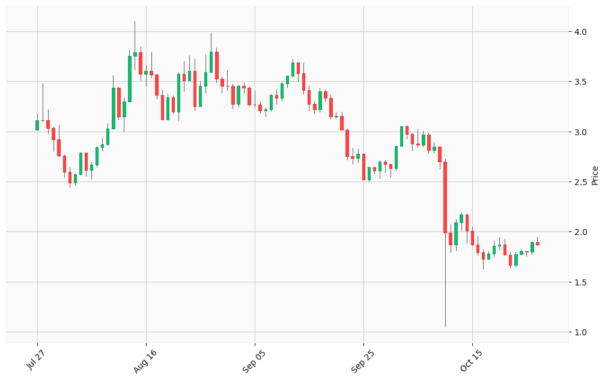

## Hourly Chart

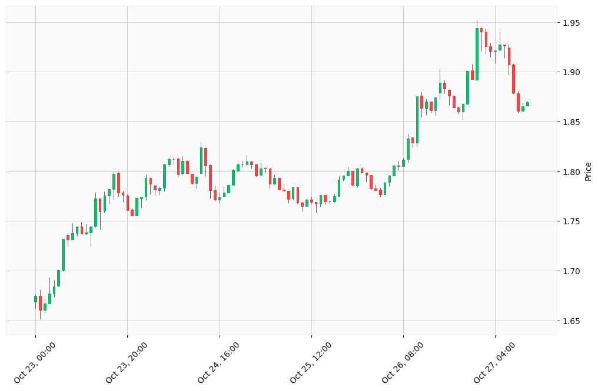

Okay, I will analyze the provided RAY-USD cryptocurrency data and generate trading signals based on the outlined steps. Due to the limitations of directly accessing and processing real-time news and economic data within this environment, I will focus on the technical analysis of the provided OHLCV data. I will use trend analysis and basic technical indicators based on the data you’ve provided to create potential buy/sell signals.

Let’s start by generating search queries to gather more information for RAY-USD

Okay, I’ve reviewed the search results. Here’s a summary of the relevant information I can use for the analysis:

- **Raydium (RAY):** It’s an automated market maker (AMM) and liquidity provider on the Solana blockchain, working with the Serum decentralized exchange (DEX).
- **Technical Indicators:** Common indicators used in crypto trading include Moving Averages (MA), Relative Strength Index (RSI), MACD, Bollinger Bands, Stochastic Oscillator.
- **RAY Price:** Recent data indicates a price around $1.88 to $1.94. There have been fluctuations, including a rise in the past 24 hours, but a decrease over the last month.
- **Market Sentiment:** Mixed sentiment exists. Some analysts point to bullish continuation setups, while others note negative divergence and potential short opportunities.
- **Recent News:** Recent news (October 2025) suggests a surge in Q3 revenue driven by LaunchLab, and significant buybacks of RAY tokens. However, there’s also increasing competition from other DEXs like Meteora.
- **Technical Analysis Ratings:** Some sources show an overall “sell” rating based on technical indicators.

Now, I will proceed with analyzing the provided OHLCV data.

```python
import pandas as pd
import numpy as np

# Daily Chart Data
daily_data = """
3.01959,3.18169,3.01493,3.11427,59316306
3.11427,3.48719,3.09695,3.11065,166758568
3.11066,3.21832,2.97752,3.03305,73888603
3.03305,3.05063,2.80047,2.91906,61507252
2.91906,3.06826,2.74422,2.75848,55310359
2.75847,2.77179,2.54524,2.59509,81645640
2.59509,2.64322,2.44054,2.48737,56074249
2.48727,2.5856,2.46216,2.57146,34555618
2.57146,2.79571,2.56728,2.79109,49766878
2.79109,2.79415,2.55335,2.61649,56092585
2.61639,2.70146,2.52509,2.66663,54198778
2.66663,2.85589,2.64286,2.84005,56533497
2.84016,2.94098,2.80861,2.87536,58404320
2.87536,3.0858,2.86236,3.03077,64956983
3.03077,3.56425,3.02872,3.43908,419464210
3.43903,3.44697,3.11873,3.15123,142619710
3.15122,3.33982,2.99885,3.29602,152989441
3.29602,3.81848,3.29103,3.75792,336902571
3.75792,4.10307,3.6187,3.78933,453397188
3.7897,3.85208,3.50783,3.5776,165180304
3.5776,3.66645,3.45232,3.6047,86089362
3.6047,3.79485,3.53708,3.5684,117185618
3.5684,3.57705,3.32346,3.36532,105832532
3.36532,3.41798,3.11619,3.11803,74707751
3.11803,3.37673,3.11693,3.3393,80903621
3.3393,3.36711,3.17606,3.19419,64812484
3.19419,3.59386,3.10782,3.5723,130279660
3.57234,3.70983,3.40041,3.50719,112989386
3.50729,3.76142,3.50727,3.60693,192632805
3.60693,3.73053,3.20874,3.25274,140844447
3.25274,3.50349,3.2494,3.45527,119655249
3.45513,3.77227,3.38231,3.59056,193191191
3.59056,3.98756,3.59042,3.79621,325949386
3.7966,3.8419,3.48345,3.52901,163971635
3.52905,3.54815,3.38045,3.45698,81436538
3.45698,3.6198,3.40715,3.45549,96352862
3.45549,3.48139,3.22616,3.2738,94603842
3.2738,3.46893,3.24755,3.4559,86393986
3.4559,3.49247,3.38565,3.4344,57037546
3.4344,3.44895,3.25376,3.26683,47660415
3.26683,3.41456,3.23923,3.26712,68172097
3.26712,3.3051,3.18323,3.20679,30394847
3.20679,3.24453,3.15038,3.21953,41552671
3.21953,3.37506,3.2054,3.36312,81507897
3.36312,3.42737,3.26792,3.33333,90988476
3.33333,3.49776,3.30607,3.47696,101688131
3.47696,3.55985,3.43989,3.55425,79019027
3.55425,3.73185,3.53809,3.6914,117970282
3.6914,3.69795,3.499,3.57985,87427253
3.57985,3.68687,3.37147,3.41143,75433884
3.41143,3.45945,3.20635,3.27379,67297285
3.27376,3.30283,3.17863,3.21863,55073750
3.21863,3.4362,3.18977,3.40015,83528756
3.40015,3.41813,3.29757,3.33536,75045965
3.33536,3.37223,3.12423,3.14748,67087012
3.14748,3.19902,3.12903,3.15343,38920491
3.15343,3.19507,3.01898,3.01898,48296193
3.01898,3.02619,2.71624,2.75447,95310585
2.75447,2.83839,2.67529,2.73763,50218544
2.73763,2.83049,2.68709,2.7757,40022757
2.77571,2.7843,2.51961,2.52089,70633649
2.52089,2.64309,2.50241,2.64285,46856044
2.64285,2.64353,2.5798,2.60892,24111523
2.60892,2.71458,2.52888,2.70119,31299987
2.70119,2.71497,2.5885,2.67547,38537510
2.67547,2.67758,2.54482,2.63481,38591566
2.63481,2.85523,2.6074,2.85494,49350642
2.85492,3.05767,2.8518,3.054,73001512
3.054,3.06257,2.92514,2.97565,53803456
2.97565,2.98442,2.80574,2.87711,37833984
2.8771,3.03074,2.84521,2.86519,48299171
2.86519,3.00416,2.84591,2.96874,47166110
2.96874,2.98883,2.78302,2.81552,56391491
2.81552,2.89622,2.78339,2.84663,36255391
2.84663,2.84666,2.62835,2.69672,48408588
2.6968,2.73143,1.0477,1.9897,144159728
1.98972,2.07411,1.79443,1.87035,91566212
1.87035,2.12818,1.81157,2.09034,74217363
2.09043,2.18609,2.00986,2.17087,59089112
2.17087,2.18206,1.88245,2.01065,74014163
2.01065,2.05149,1.85836,1.87115,47399687
1.87115,1.96294,1.7623,1.79147,60634598
1.79147,1.82086,1.6243,1.72719,58904702
1.72719,1.80299,1.72669,1.77921,26382545
1.77925,1.90967,1.74736,1.85841,38025107
1.85841,1.95061,1.81813,1.87314,40941040
1.87327,1.93273,1.76671,1.76985,46913563
1.76985,1.80096,1.63749,1.66841,46147095
1.66841,1.79989,1.65056,1.77404,34467855
1.77407,1.83036,1.76743,1.80716,27097782
1.8072,1.80982,1.75859,1.79885,22501837
1.79883,1.90839,1.77377,1.89254,33911857
1.89266,1.94629,1.85836,1.86967,40996372
"""

# Hourly Chart Data
hourly_data = """
1.66845,1.67609,1.66153,1.67486,0
1.67491,1.68131,1.65093,1.66062,0
1.66038,1.67234,1.65763,1.66679,0
1.66677,1.6934,1.66677,1.67706,787936
1.67697,1.6907,1.67341,1.68435,0
1.68445,1.70059,1.68445,1.70059,0
1.70054,1.7319,1.69959,1.7319,608540
1.73592,1.73766,1.72401,1.73145,865668
1.7312,1.74808,1.7312,1.73779,31028
1.73772,1.74445,1.73471,1.74445,1240
1.74417,1.74896,1.73738,1.73745,0
1.73729,1.74713,1.73631,1.73822,0
1.73848,1.7455,1.72456,1.74458,711852
1.74485,1.77934,1.74346,1.77256,497488
1.77263,1.77263,1.74146,1.7598,0
1.76006,1.77959,1.75833,1.77568,0
1.77558,1.78216,1.76722,1.78208,0
1.78222,1.79957,1.7713,1.79772,776824
1.7979,1.79926,1.77459,1.77883,161088
1.77886,1.78022,1.76891,1.7761,0
1.77591,1.77664,1.76104,1.76104,0
1.76152,1.76327,1.75508,1.75567,0
1.75569,1.77302,1.75569,1.77302,0
1.77295,1.77414,1.76327,1.77405,0
1.77436,1.7967,1.77117,1.7936,229340
1.79348,1.79348,1.77706,1.78748,0
1.78592,1.78592,1.77591,1.78145,0
1.78089,1.78463,1.77608,1.78331,0
1.78332,1.80726,1.77959,1.80715,579786
1.80718,1.81341,1.80494,1.81225,395260
1.81216,1.81421,1.80721,1.81252,104456
1.81265,1.81407,1.79424,1.79699,0
1.79786,1.81532,1.79645,1.81048,0
1.81065,1.81086,1.79779,1.79782,40794
1.79774,1.79774,1.78684,1.78816,0
1.788,1.79436,1.78235,1.79436,0
1.79797,1.82923,1.79797,1.8241,908896
1.82375,1.82383,1.79492,1.80586,0
1.80632,1.80721,1.77285,1.78115,0
1.78111,1.78541,1.76995,1.77153,0
1.77174,1.77881,1.76775,1.77407,0
1.77425,1.78468,1.77425,1.77862,0
1.77859,1.78639,1.77793,1.78639,0
1.78633,1.80211,1.78633,1.80091,0
1.8006,1.80916,1.80024,1.80717,0
1.80685,1.81056,1.80372,1.80689,0
1.80707,1.8165,1.80583,1.81017,0
1.81006,1.81006,1.8026,1.80709,0
1.80721,1.80729,1.79465,1.79597,0
1.79633,1.80945,1.79612,1.80273,0
1.80319,1.80382,1.79866,1.80269,0
1.80273,1.80273,1.78273,1.78737,168256
1.78726,1.79692,1.78706,1.79326,0
1.79311,1.79311,1.78135,1.78145,0
1.78172,1.78739,1.78048,1.78048,0
1.78053,1.78053,1.76811,1.77234,45236
1.77241,1.7837,1.77146,1.7837,0
1.7837,1.7838,1.76726,1.76828,0
1.76857,1.76904,1.75976,1.76514,0
1.76523,1.77353,1.76492,1.77156,0
1.7716,1.77467,1.76746,1.76918,0
1.76888,1.76888,1.75859,1.76715,0
1.76729,1.77632,1.76438,1.77632,0
1.77618,1.77618,1.76676,1.7697,0
1.76961,1.77069,1.76684,1.76985,0
1.76997,1.77717,1.76859,1.77488,0
1.77479,1.79549,1.77458,1.79172,0
1.79198,1.79557,1.7905,1.79557,0
1.79576,1.80487,1.79576,1.80021,111746
1.80033,1.80033,1.78527,1.78606,0
1.78592,1.80326,1.78399,1.80308,1719542
1.8031,1.80386,1.79894,1.79894,441010
1.79883,1.79883,1.78931,1.79654,183704
1.79607,1.79607,1.78152,1.78279,249280
1.783,1.78708,1.78013,1.78124,510710
1.78132,1.78362,1.77381,1.77661,0
1.77655,1.78912,1.77655,1.78855,382128
1.78905,1.79588,1.7853,1.79588,0
1.79581,1.8059,1.79501,1.8059,0
1.80584,1.81039,1.80133,1.80539,0
1.80546,1.81323,1.80546,1.8117,0
1.81256,1.83779,1.80868,1.83294,653330
1.83441,1.83441,1.82396,1.82899,230716
1.82892,1.87576,1.82487,1.87576,1283568
1.87618,1.88017,1.85439,1.86343,0
1.86362,1.87324,1.85666,1.87004,318234
1.86993,1.8703,1.85873,1.86125,177162
1.86144,1.87408,1.8559,1.87408,125578
1.87881,1.90319,1.87261,1.88921,3986936
1.88934,1.89228,1.87835,1.88339,1124198
1.8822,1.8822,1.86641,1.8763,730258
1.87626,1.87626,1.86308,1.86405,617176
1.8645,1.86524,1.85724,1.86039,701340
1.85994,1.86794,1.85161,1.86768,513168
1.8677,1.90137,1.8677,1.90106,937922
1.90124,1.90818,1.89239,1.89239,694420
1.8923,1.95168,1.8923,1.94416,2120820
1.94373,1.94541,1.92082,1.94069,1390804
1.94057,1.94419,1.91879,1.92546,607976
1.92546,1.9295,1.91513,1.92096,505448
1.92076,1.92152,1.90855,1.92142,63000
1.92204,1.94074,1.92204,1.9277,711540
1.92762,1.92762,1.91411,1.9267,541712
1.92455,1.92825,1.89668,1.90733,470788
1.90736,1.9083,1.8777,1.87926,1110952
1.87865,1.88132,1.85826,1.86061,504804
1.86064,1.86913,1.85994,1.86566,191924
1.86591,1.87058,1.86591,1.86967,18800
"""

# Convert data to Pandas DataFrames
daily_df = pd.read_csv(io.StringIO(daily_data), header=None, names=['Open', 'High', 'Low', 'Close', 'Volume'])
hourly_df = pd.read_csv(io.StringIO(hourly_data), header=None, names=['Open', 'High', 'Low', 'Close', 'Volume'])

# Print the DataFrames to verify
print("Daily Data:")
print(daily_df.head())
print("\nHourly Data:")
print(hourly_df.head())
```

[output not shown]